# Reproducibe Research, Course Project 1

Maxim Ogarenko

24 October 2018 г

## Introduction

It is now possible to collect a large amount of data about personal movement using activity monitoring devices.

This assignment makes use of data from a such a device, which collects data at 5 minute intervals through out the day. The data consists of two months of data from an anonymous individual collected during the months of October and November, 2012 and include the number of steps taken in 5 minute intervals each day.

The original data is downloadable [here](https://d396qusza40orc.cloudfront.net/repdata%2Fdata%2Factivity.zip).

## 1. Code for reading the dataset and processing the data

Firstly, I download, unzip and read the original data into a CSV dataset.

Secondly, I load the necessary R libraries (dplyr and ggplot2).

Thirdly, I do the preliminary data exploration.

```
## [1] "The dataset is of the data.frame class."
```

```
## [1] "The dataset has the following dimensions:"
```

```
## [1] 17568     3
```

```
## [1] "The columns have the following names:"
```

```
## [1] "steps"    "date"     "interval"
```

```
## [1] "The beginning of the dataset looks like this:"
```

```
##   steps       date interval
## 1    NA 2012-10-01        0
## 2    NA 2012-10-01        5
## 3    NA 2012-10-01       10
## 4    NA 2012-10-01       15
## 5    NA 2012-10-01       20
## 6    NA 2012-10-01       25
```

```
## [1] "There are observations for 61 consequent days,"
```

```
## [1] "Each day is divided into 288 5-minutes intervals."
```

## 2. Histogram of the total number of steps taken each day

To analyze the daily number of steps distribution, I summarize the dataset by dates and build the histogram.

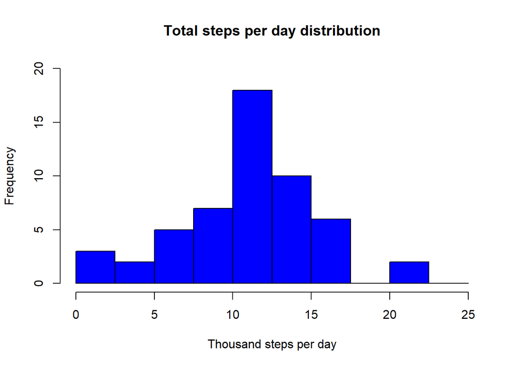

## 3. Mean and median number of steps taken each day

```
## [1] "The mean number of steps per day is  10.8 thousand"
```

```
## [1] "The median number of steps per day is  10.8 thousand"
```

## 4. Time series plot of the average number of steps taken

The average daily pattern for the number of steps per 5-minutes interval is the following:

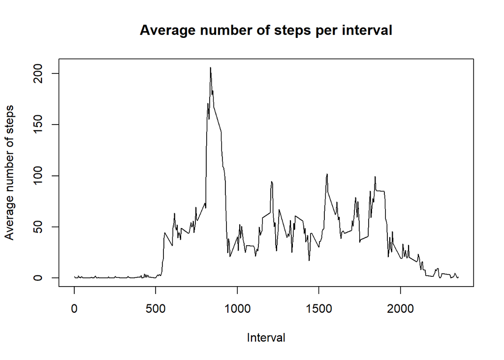

## 5. The 5-minute interval that, on average, contains the maximum number of steps

```
## [1] "Interval # 835 on average, contains the maximum number of steps"
```

## 6. Code to describe and show a strategy for imputing missing data

```
## [1] "In the original dataset,  13.1 percent  of observations contain missing data for steps."
```

I chose to replace those missing data with daily averages for the respective time intervals.

## 7. Histogram of the total daily number of steps after NAs are imputed

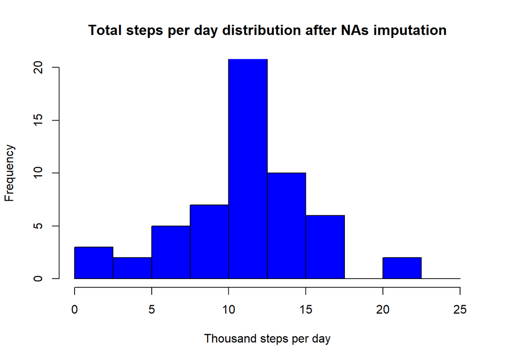

## 8. Average number of steps per 5-minute interval, weekdays VS weekends

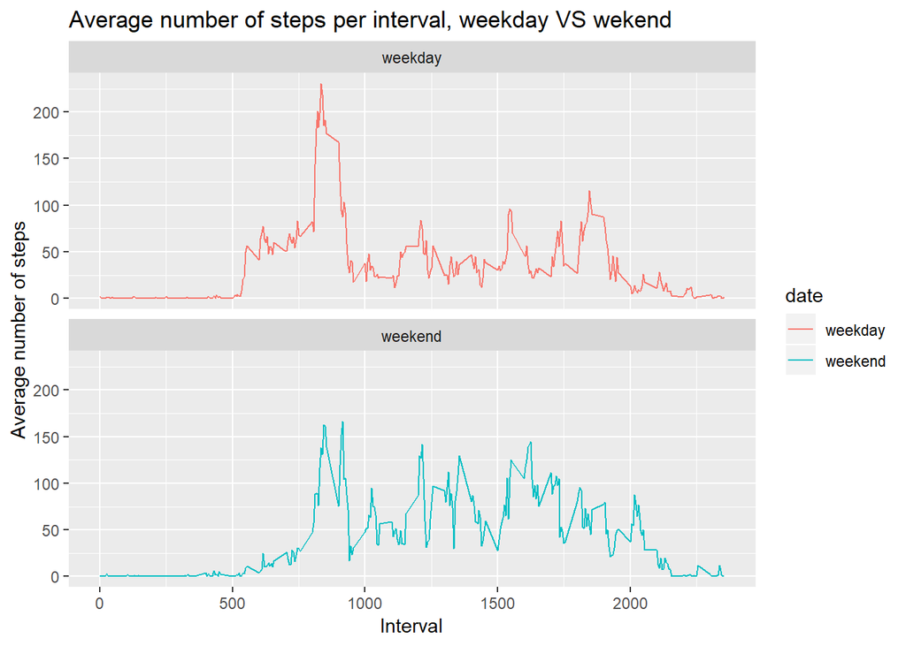